# NFL Predictions Report

Tony

November 14, 2017

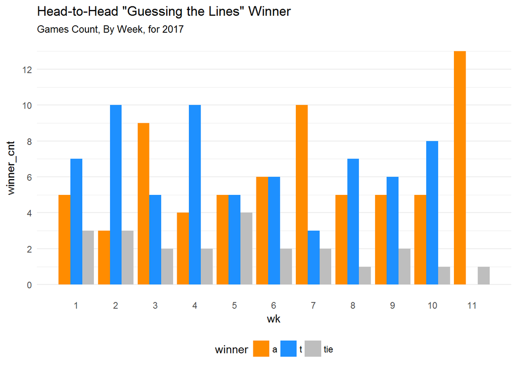

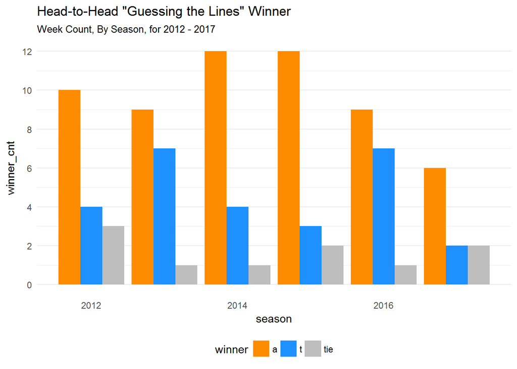

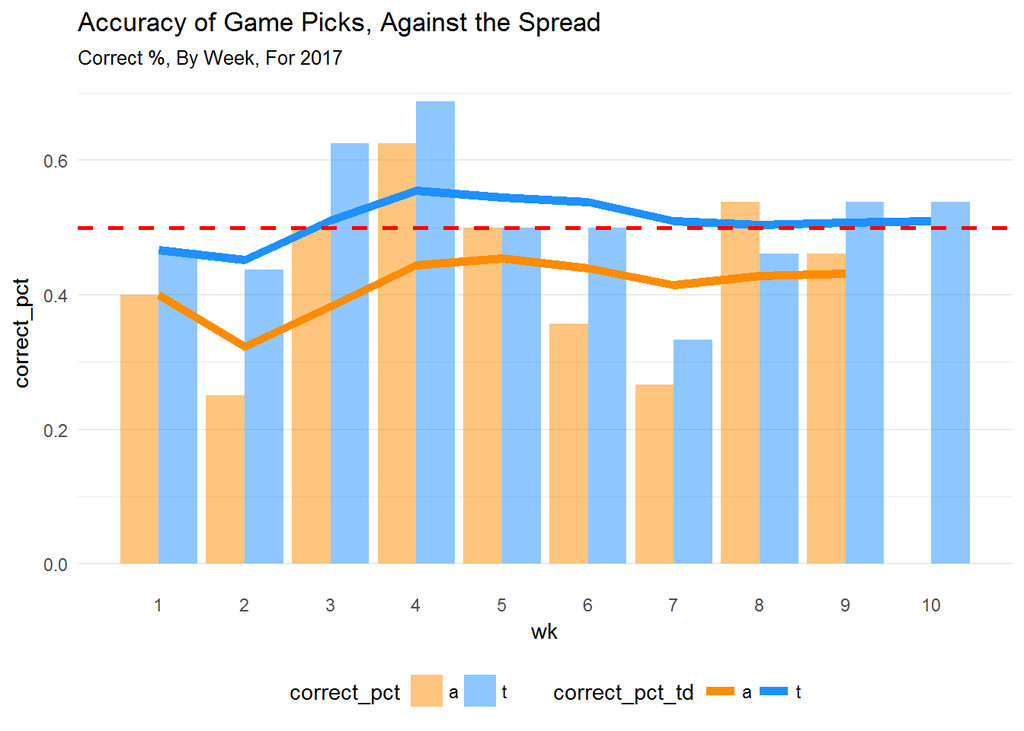

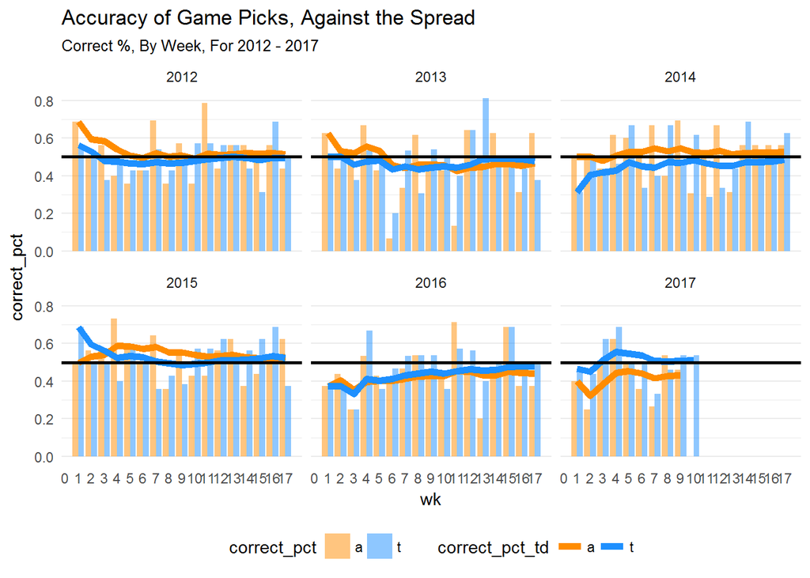

# Current Season

## By Week

# A tibble: 5 x 5

# Groups: season [1]

season wk a t tie 1 2017 7 10 3 2 2 2017 8 5 7 1 3 2017 9 5 6 2 4 2017 10 5 8 1 5 2017 11 13 NA 1

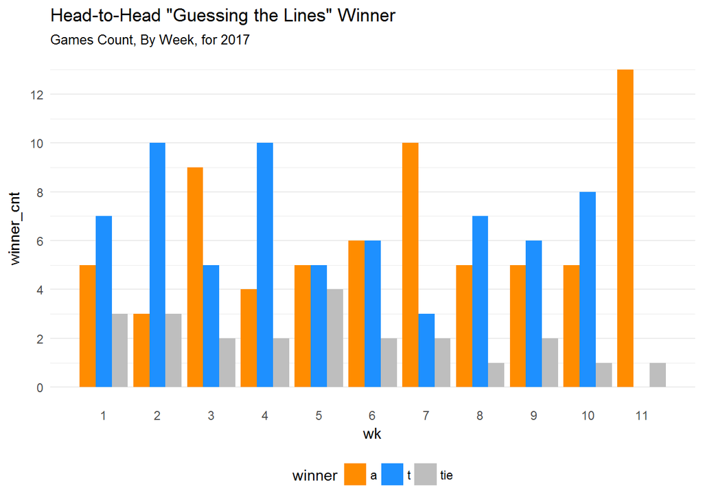

# A tibble: 10 x 7

# Groups: season, person [2]

season wk person correct incorrect correct_pct correct_pct_td 1 2017 6 a 5 9 0.3571429 0.4395604 2 2017 6 t 7 7 0.5000000 0.5384615 3 2017 7 a 4 11 0.2666667 0.4150943 4 2017 7 t 5 10 0.3333333 0.5094340 5 2017 8 a 7 6 0.5384615 0.4285714 6 2017 8 t 6 7 0.4615385 0.5042017 7 2017 9 a 6 7 0.4615385 0.4318182 8 2017 9 t 7 6 0.5384615 0.5075758 9 2017 10 a NA 13 NA NA 10 2017 10 t 7 6 0.5384615 0.5103448

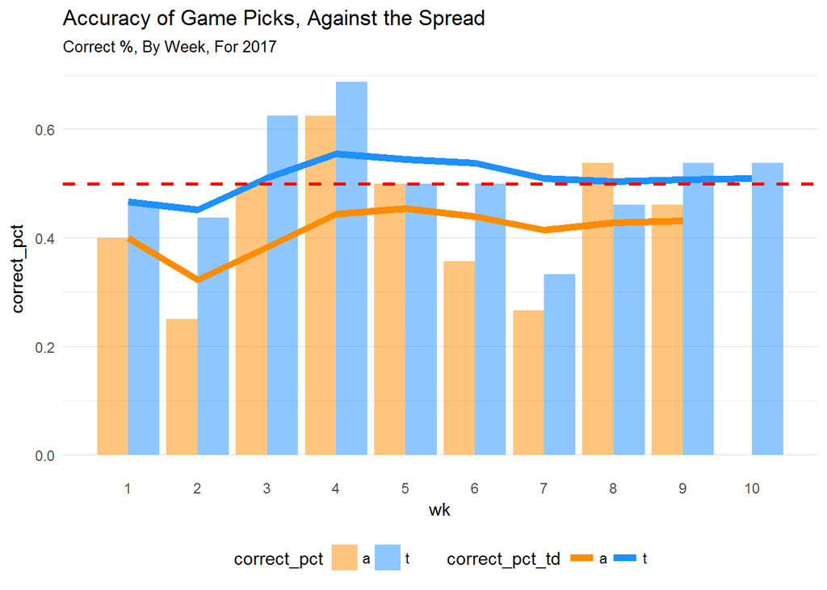

# All Seasons

## By Season

# A tibble: 5 x 4

# Groups: season [5]

season a t tie 1 2013 9 7 1 2 2014 12 4 1 3 2015 12 3 2 4 2016 9 7 1 5 2017 6 2 2

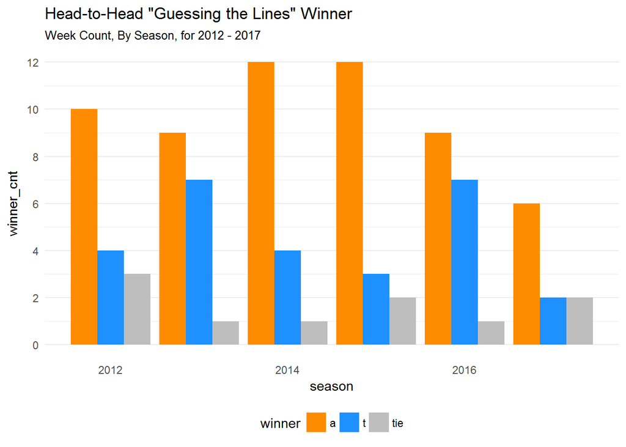

# A tibble: 10 x 7

# Groups: season, person [2]

season wk person correct incorrect correct_pct correct_pct_td 1 2017 6 a 5 9 0.3571429 0.4395604 2 2017 6 t 7 7 0.5000000 0.5384615 3 2017 7 a 4 11 0.2666667 0.4150943 4 2017 7 t 5 10 0.3333333 0.5094340 5 2017 8 a 7 6 0.5384615 0.4285714 6 2017 8 t 6 7 0.4615385 0.5042017 7 2017 9 a 6 7 0.4615385 0.4318182 8 2017 9 t 7 6 0.5384615 0.5075758 9 2017 10 a NA 13 NA NA 10 2017 10 t 7 6 0.5384615 0.5103448

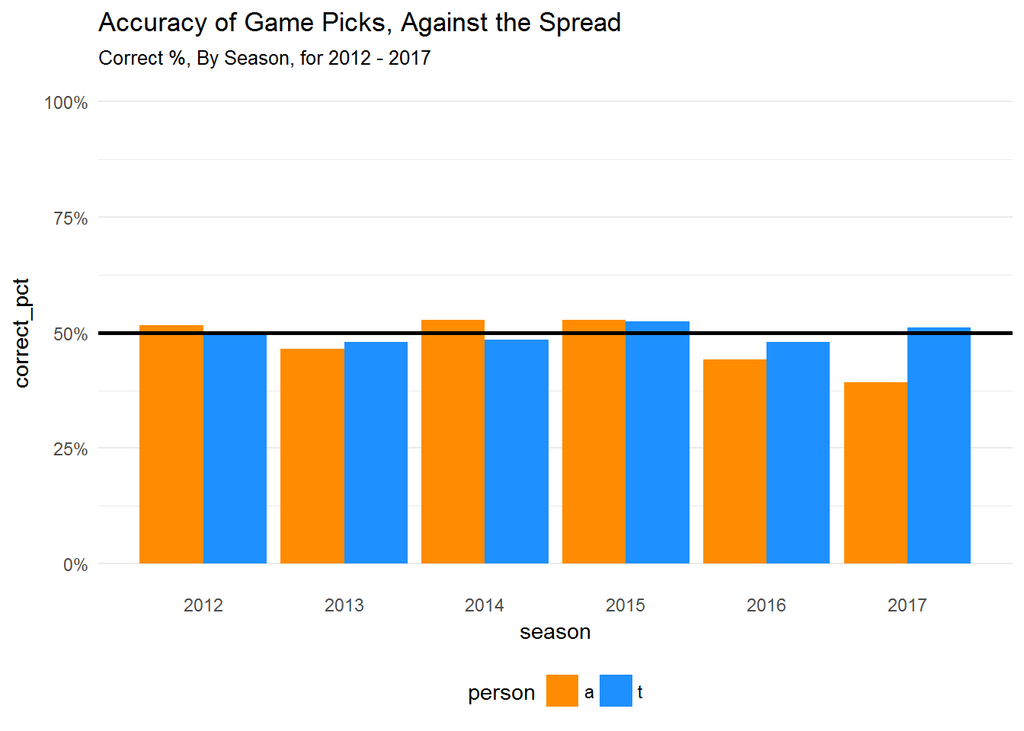